# Final Project STAT1010

Kian Speck

2/4/2022

# Introduction

#### Required libraries for this project

```r
# data management
library(soilDB)
library(aqp)
library(dplyr)
library(sf)
library(viridis)
library(broom)
library(sharpshootR)
# plotting
library(ggmap)
library(raster)
library(cowplot)
```

### Project Area

Latah County is an important agricultural area with a topographically diverse landscape. Located in north-central Idaho, this county provides important agricultural goods, such as wheat and barley, to the rest of the state. It is for this reason that soils are treated as an especially valuable resource in this region. Soils are so important, in fact, that Latah county was home to Idaho’s first soil conservation district.

Additionally, Latah county has a diverse range of topography. The western portion of the region contains the rolling hills of the Palouse prairie, and to the south the Potlatch river forms deep canyons as it cuts through loess-covered hills. Elevations in the area range from 1,000 to almost 5,000 feet as a result. Topography is a major soil-forming factor (Jenny 1994) and therefore variation in soils tend to follow gradients of topography in parts of the region. For example, changes in slope along these topographic gradients modulate the intensity of processes like erosion and water movement. Soil properties such as clay content and depth vary along these gradients as a result.

Regional soil scientists have a vast knowledge of many of these soil-landscape relationships. However, explicitly researching and documenting the range of soil characteristics along a topographic transect (also known as a toposequence) is often not done in regional Soil Survey offices. The purpose of this project is to gather greater detail on a specific toposequence important to this region in order to provide evidence for conventional wisdom relating to soil-landscape models.

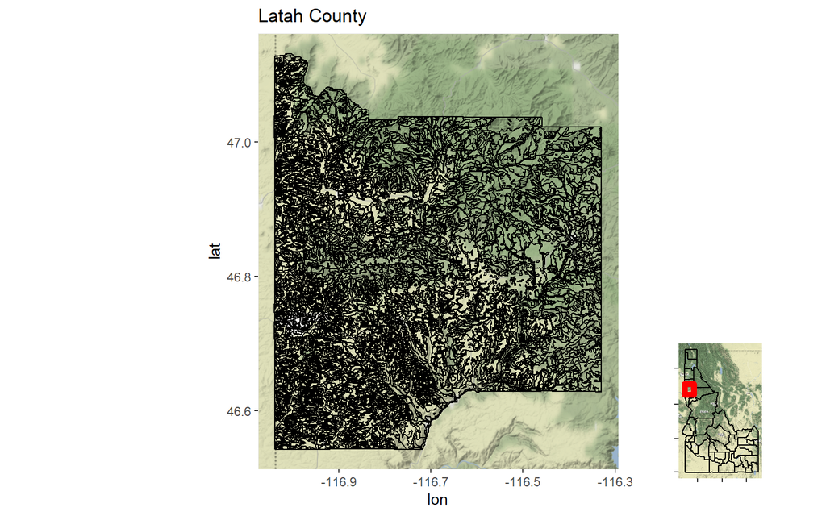

Figure 1: Soil map of Latah County with inset map of Idaho as reference to geographic location

```r
# load idaho counties and latah county shapefiles
idaho <- read_sf("C:\\ArcGIS\\SHAPEFILE\\IdahoCounties.shp")
latah_sm <- read_sf("C:\\ArcGIS\\BASE\\ID057\\spatial\\soilmu_a_id057.shp")

# simplify and convert Latah to tidy object for plotting
lsimple <- rmapshaper::ms_simplify(latah_sm)
l_tidy <- tidy(as(lsimple, "Spatial"), region = "MUSYM")

# create tidy object from idaho sf for plotting
ID_tidy <- tidy(as(idaho, "Spatial"), region = 'NAME')

# create bounding box for latah
bb <- sf::st_bbox(lsimple)
bb <- make_bbox(lon = bb[c(3, 1)], lat = bb[c(2, 4)])

# create bounding box for idaho
bb2 <- sf::st_bbox(idaho)
bb2 <- make_bbox(lon = bb2[c(3, 1)], lat = bb2[c(2, 4)])

# create second bounding box for latah
bb.l <- as(extent(lsimple), 'SpatialPolygons')
# define coordinates
proj4string(bb.l) <- CRS('+proj=longlat +datum=WGS84 +no_defs')
#transform into dataframe
bb.l.df <- fortify(bb.l)

## create maps
# larger latah map
gmap <- get_map(bb, maptype = "terrain", source = "osm")

latah_gg <- ggmap(gmap) +
  geom_path(data = l_tidy, aes(x = long, y = lat, group = group)) +
  ggtitle('Latah County')

#smalle idaho map with latah bounding box
gmap2 <- get_map(bb2, maptype = "watercolor", source = "osm")

idaho_gg <- ggmap(gmap2) +
  geom_path(data = ID_tidy, aes(x = long, y = lat, group = group)) +
  theme(
    axis.title.x = element_blank(),
    axis.title.y = element_blank(),
    axis.text.x =  element_blank(),
    axis.text.y = element_blank()
  ) +
  geom_polygon(
    data = bb.l,
    aes(x = long, y = lat, group = group),
    colour = 'red',
    fill = NA,
    size = 2
  )

#combine latah and idaho map into one plot
gg_inset <- ggdraw()+
  draw_plot(latah_gg)+
  draw_plot(idaho_gg, x = 0.72, y = 0.05, width = 0.3, height = 0.3)+
  theme(plot.margin = unit(c(0,0,0,0), 'cm'))

# plot
gg_inset
```

## Objectives

The objectives of this project are:

1. Compare the the typical soil profiles for three series: **Threebear**, **Norwidge**, and **Porrett**.
2. Compare the average geomorphic positions of the series and create a toposequence.
3. Utilize descriptive statistics to examine clay content and average depth along the toposequence.

# Results

### Objective 1: Comparing series morpholgies

Compare plots of the OSD pedons

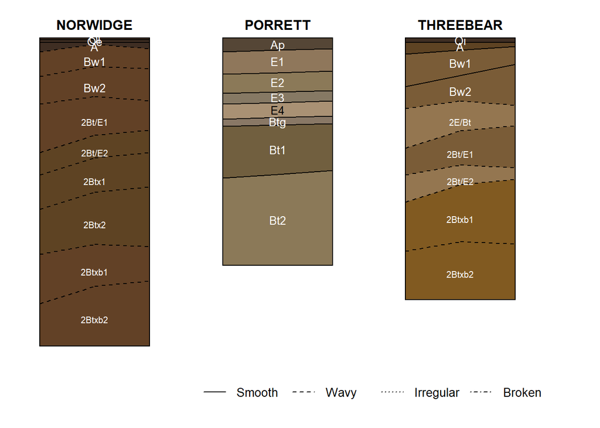

Figure 2: Plot of OSD pedons for Norwidge, Porrett and Threebear with horizon topography represented.

```r
# fetch OSD's for series of interest
soi <- c('norwidge','porrett','threebear')
osdp <- fetchOSD(soi)

# encode horizon boundary distinctness
osdp$hd <- hzDistinctnessCodeToOffset(osdp$distinctness,
                                      codes = c('very abrupt', 'abrupt', 'clear', 'gradual', 'diffuse'))

# encode horizon boundary topography
osdp$hzto <- hzTopographyCodeToOffset(osdp$topography,
                                      codes = c('smooth', 'wavy', 'irregular', 'broken'))

# also encode horizon boundary topography las line type
osdp$hzto.lty <- hzTopographyCodeToLineType(osdp$topography,
                                            codes = c('smooth', 'wavy', 'irregular', 'broken'))


# concise representation of hz bnd distinctness and topography
# # similar to field notes
osdp$bnd.code <- sprintf("%s%s",
                         substr(osdp$distinctness, 1, 1),
                         substr(osdp$topography, 1, 1))

# remove NA
osdp$bnd.code <- gsub('NANA', '', osdp$bnd.code)

# plot
par(mar = c(0, 0, 0, 1), bg = 'white', fg = 'black')

plotSPC(
  osdp,
  width = 0.3,
  name.style = 'center-center',
  cex.names = 0.8,
  plot.depth.axis = FALSE,
  hz.depths = FALSE,
  shrink = TRUE,
  hz.distinctness.offset = 'hd',
  hz.topography.offset = 'hzto',
  hz.boundary.lty = 'hzto.lty'
)

# add legend
legend(
  'bottomright',
  horiz = TRUE,
  legend = c('Smooth', 'Wavy', 'Irregular', 'Broken'),
  lty = 1:4,
  inset = 0.05,
  bty = 'n',
  cex = 0.85
)
```

These soils range from a fragipan in Threebear to fragic properties in Norwidge and then finally a strong argillic in Porrett. There are also significant color differences along with differences in horizon topography. Porrett has the smoothest horizon boundaries compared to the wavy boundaries of the other two series. Furthermore, Porrett has a large section of eluviation, whereas the other series have very little, and Threebear has some interfingering of E into the Bt horizons.

### Objective 2: Create toposequence

The first step is to get the average geomorphic positions of each series.

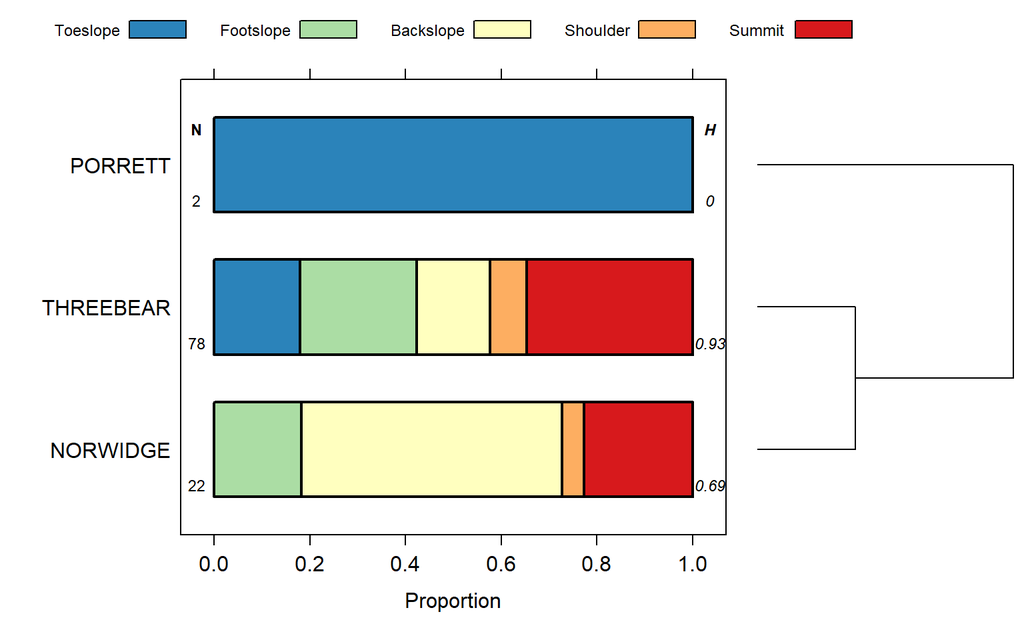

Figure 3: Plot showing the proportions of pedons in each series found on five different hillslope positions.

```r
# fetch OSDs with extended data
s <- fetchOSD(soi, extended = TRUE)
# gather hillslope positions
res <- vizHillslopePosition(s$hillpos)
# plot
print(res$fig)
```

Then, plot a dendogram using the catenary sorting.

```r
#order of dominant position from summit to toeslope
s$hillpos
```

```
##      series Toeslope Footslope Backslope Shoulder Summit  n shannon_entropy
## 1  NORWIDGE   0.0000    0.1818    0.5455   0.0455 0.2273 22       0.6945788
## 2   PORRETT   1.0000    0.0000    0.0000   0.0000 0.0000  2       0.0000000
## 3 THREEBEAR   0.1795    0.2436    0.1538   0.0769 0.3462 78       0.9349531
```

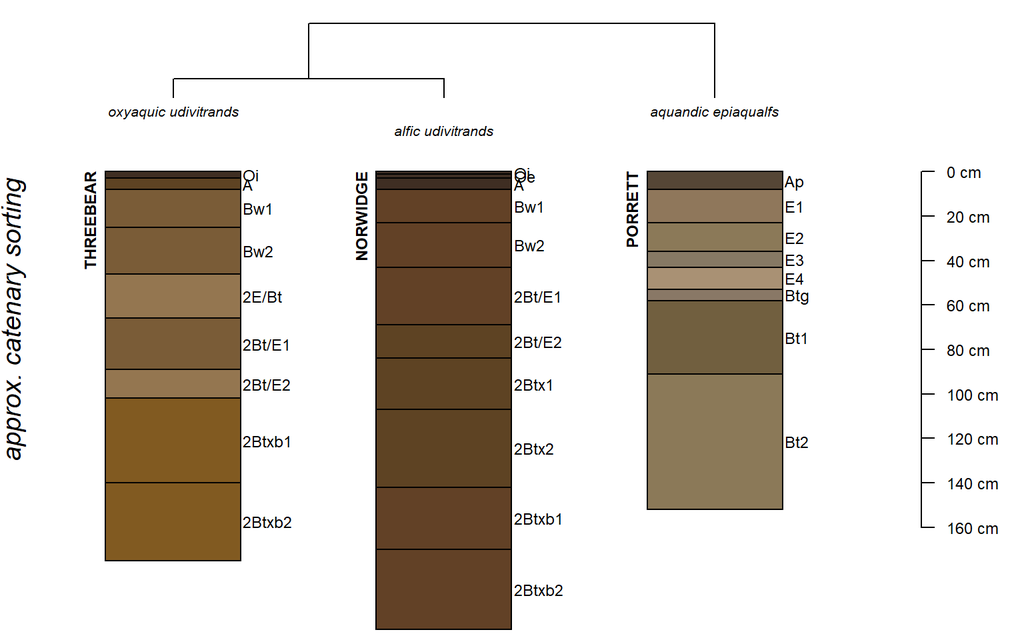

Figure 4: Plot showing the representative pedons for each series in order of cantenary position, starting with summit on the left to toeslope on the right. Branches represent taxonomic relationships and distance between the three series.

```r
labs <- c(2,1,3)

# plot
par(mar=c(0,0,1,1))
SoilTaxonomyDendrogram(s$SPC, rotationOrder = labs, width=0.25)
mtext('approx. catenary sorting', side = 2, line=-1, font=3, cex=1.25)
```

The series, ordered from summit to toeslope, are Threebear, Norwidge, and Porrett. While Threebear is dominantly found in the summit position, there is some overlap with Norwidge as they both occur on the backslope, footslope, and summit. Porrett, on the other hand, is only found in the toeslope position. There is also a relationship between the taxonomic classes along the catenary sequence. The Udivitrands are on the upper parts of the slope and go from an Oxyaquic subgroup to a Alfic subgroup, which may be evidence of the varying hydrological processes along the topographic gradient. Finally, at the toeslope position Porrett is the farthest away taxonomically as an Aquandic Epiaqualf. The shift from Andisols to an Alfisol also indicates that topographic position is modulating the presence of volcanic ash in the soil.